# Биостатистика, дз 3

Мухина А.А.

2024-03-28

Вначале загрузим библиотеки

```r
library(readxl)
library(tidyverse)
library(dplyr)
```

Теперь загрузим данные

```r
setwd('C:/Users/79169/Desktop/IDE')

pima <- read_excel("pima.xlsx")

head(pima)
```

```
## # A tibble: 6 × 9
##   pregnant glucose pressure triceps insulin  mass pedigree   age diabetes
##      <dbl>   <dbl>    <dbl>   <dbl>   <dbl> <dbl>    <dbl> <dbl> <chr>
## 1        6     148       72      35       0  33.6    0.627    50 pos
## 2        1      85       66      29       0  26.6    0.351    31 neg
## 3        8     183       64       0       0  23.3    0.672    32 pos
## 4        1      89       66      23      94  28.1    0.167    21 neg
## 5        0     137       40      35     168  43.1    2.29     33 pos
## 6        5     116       74       0       0  25.6    0.201    30 neg
```

Задание 1

Рассчитайте описательные статистики для переменных glucose, pressure, mass.

Все 3 переменные являются количесивенными, соответственно, для них нужно рассчитать число наблюдений, среднее, стандартное отклонение, 1-й и 3-й квартили, минимум и максимум.

```r
pima %>%
  summarise(
    glucose_obs = n(),
    glucose_mean = mean(glucose, na.rm = TRUE),
    glucose_sd = sd(glucose, na.rm = TRUE),
    glucose_quantile_1 = quantile(glucose, 0.25, na.rm = TRUE),
    glucose_quantile_3 = quantile(glucose, 0.75, na.rm = TRUE),
    glucose_min = min(glucose, na.rm = TRUE),
    glucose_max = max(glucose, na.rm = TRUE)
  )
```

```
## # A tibble: 1 × 7
##   glucose_obs glucose_mean glucose_sd glucose_quantile_1 glucose_quantile_3
##         <int>        <dbl>      <dbl>              <dbl>              <dbl>
## 1         768         121.       32.0                 99               140.
## # ℹ 2 more variables: glucose_min <dbl>, glucose_max <dbl>
```

```r
pima %>%
  summarise(
    pressure_obs = n(),
    pressure_mean = mean(pressure, na.rm = TRUE),
    pressure_sd = sd(pressure, na.rm = TRUE),
    pressure_quantile_1 = quantile(pressure, 0.25, na.rm = TRUE),
    pressure_quantile_3 = quantile(pressure, 0.75, na.rm = TRUE),
    pressure_min = min(pressure, na.rm = TRUE),
    pressure_max = max(pressure, na.rm = TRUE)
  )
```

```
## # A tibble: 1 × 7
##   pressure_obs pressure_mean pressure_sd pressure_quantile_1 pressure_quantile_3
##          <int>         <dbl>       <dbl>               <dbl>               <dbl>
## 1          768          69.1        19.4                  62                  80
## # ℹ 2 more variables: pressure_min <dbl>, pressure_max <dbl>
```

```r
pima %>%
  summarise(
    mass_obs = n(),
    mass_mean = mean(mass, na.rm = TRUE),
    mass_sd = sd(mass, na.rm = TRUE),
    mass_quantile_1 = quantile(mass, 0.25, na.rm = TRUE),
    mass_quantile_3 = quantile(mass, 0.75, na.rm = TRUE),
    mass_min = min(mass, na.rm = TRUE),
    mass_max = max(mass, na.rm = TRUE)
  )
```

```
## # A tibble: 1 × 7
##   mass_obs mass_mean mass_sd mass_quantile_1 mass_quantile_3 mass_min mass_max
##      <int>     <dbl>   <dbl>           <dbl>           <dbl>    <dbl>    <dbl>
## 1      768      32.0    7.88            27.3            36.6        0     67.1
```

Задание 2

Рассчитайте описательную статистику для переменной diabetes. Создайте на основе переменной age новую переменную age_group, которая будет отражать следующие возрастные группы: 21–35, 36–49 и 50+. Посчитайте описательную статистику для новой переменной.

Так как это качественная переменная, то нужно рассчитать абсолютную и относительные частоты.

```r
(abs_frequencies <- table(pima$diabetes))
```

```
##
## neg pos
## 500 268
```

```r
(rel_frequencies <- prop.table(table(pima$diabetes)))
```

```
##
##       neg       pos
## 0.6510417 0.3489583
```

Теперь создадим новую переменную age_group

```r
pima <- pima %>%
  mutate(age_group = ifelse(age <= 35, "21-35",
  ifelse(age <= 49, "36-49", "50+")))

pima <- mutate(pima, age_group = as.factor(age_group))

head(pima)
```

```
## # A tibble: 6 × 10
##   pregnant glucose pressure triceps insulin  mass pedigree   age diabetes
##      <dbl>   <dbl>    <dbl>   <dbl>   <dbl> <dbl>    <dbl> <dbl> <chr>
## 1        6     148       72      35       0  33.6    0.627    50 pos
## 2        1      85       66      29       0  26.6    0.351    31 neg
## 3        8     183       64       0       0  23.3    0.672    32 pos
## 4        1      89       66      23      94  28.1    0.167    21 neg
## 5        0     137       40      35     168  43.1    2.29     33 pos
## 6        5     116       74       0       0  25.6    0.201    30 neg
## # ℹ 1 more variable: age_group <fct>
```

А теперь посчитаем описательные статистики для новой переменной

```r
(abs_age <- table(pima$age_group))
```

```
##
## 21-35 36-49   50+
##   498   181    89
```

```r
(rel_age <- prop.table(table(pima$age_group)))
```

```
##
##     21-35     36-49       50+
## 0.6484375 0.2356771 0.1158854
```

Задание 3

Определите 90% доверительный интервал для переменной pedigree.

```r
(confidence_interval <- t.test(pima$pedigree, conf.level = 0.90)$conf.int)
```

```
## [1] 0.4521870 0.4915656
## attr(,"conf.level")
## [1] 0.9
```

Задание 4

Постройте график плотности вероятности для переменной glucose и отметьте на нем среднее значение. Для той же переменной постройте гистограмму. Постройте два ящика с усами для значений pos и neg соответственно переменной diabetes.

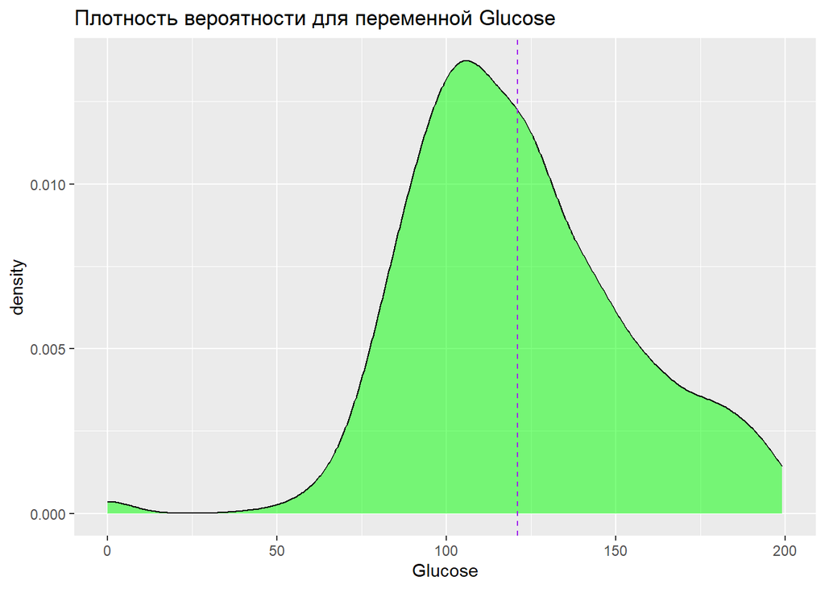

```r
ggplot(data = pima, aes(x = glucose)) +
  geom_density(fill = "green", alpha = 0.5) +
  geom_vline(aes(xintercept = mean(glucose)), color = "purple", linetype = "dashed") +
  labs(title = "Плотность вероятности для переменной Glucose", x = "Glucose")
```

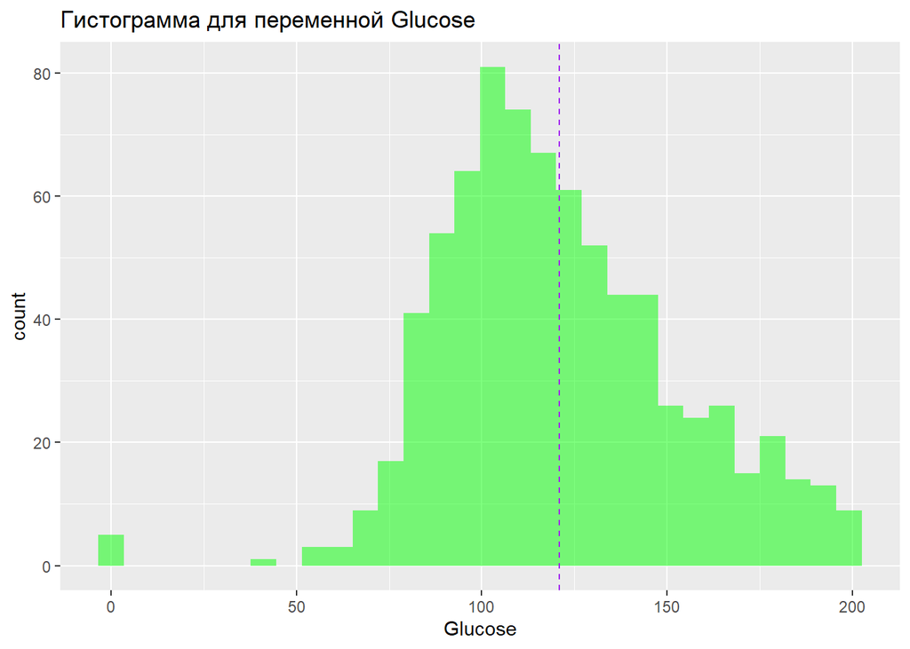

```r
ggplot(data = pima, aes(x = glucose)) +
  geom_histogram(fill = "green", alpha = 0.5) +
  geom_vline(aes(xintercept = mean(glucose)), color = "purple", linetype = "dashed") +
  labs(title = "Гистограмма для переменной Glucose", x = "Glucose")
```

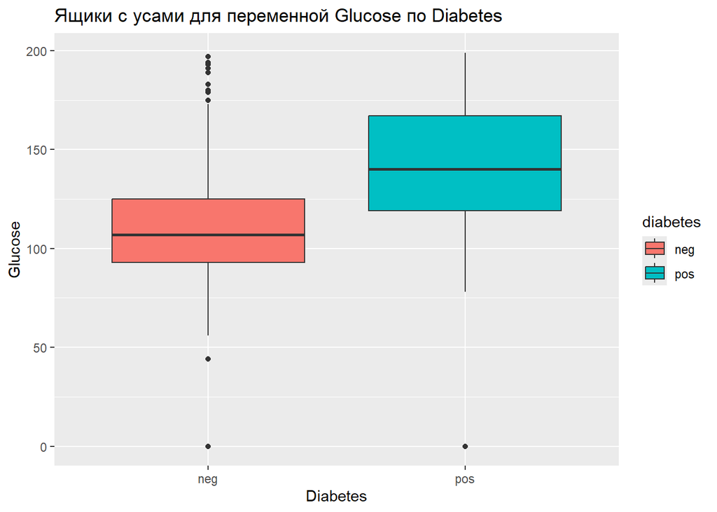

```r
ggplot(data = pima, aes(x = diabetes, y = glucose, fill = diabetes)) +
  geom_boxplot() +
  labs(title = "Ящики с усами для переменной Glucose по Diabetes", x = "Diabetes", y = "Glucose")
```

Задание 5

Постройте на одном графике две диаграммы рассеяния для наличия или отсутствия диабета. По оси X представьте значения обхвата трицепса, а по оси Y — массу тела. Выполните окрашивание, заливку и группирование по переменной diabetes.

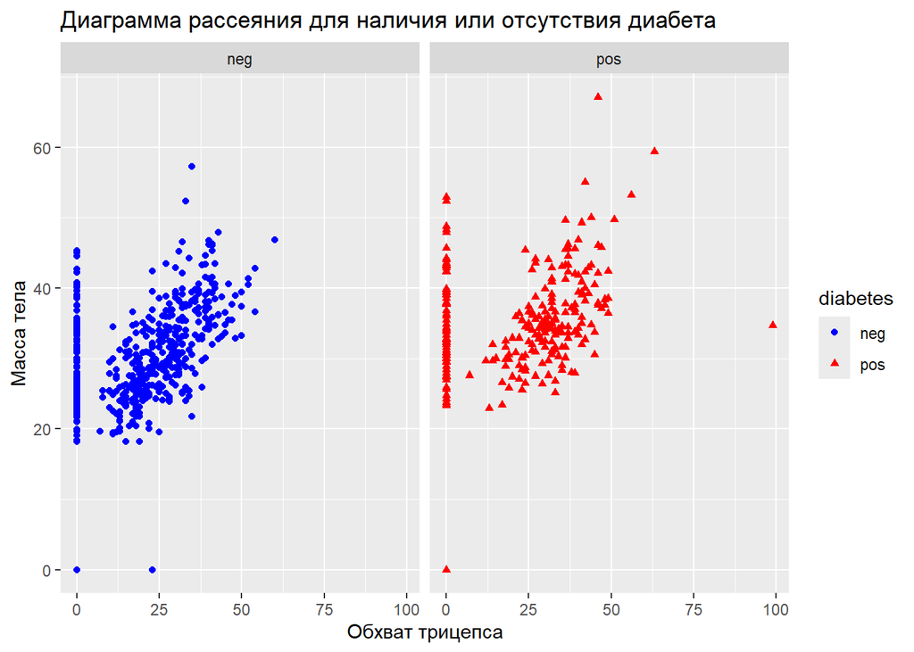

```r
ggplot(data = pima, aes(x = triceps, y = mass, color = diabetes, fill = diabetes, shape = diabetes)) +
  geom_point() +
  facet_grid(.~diabetes) +
  scale_color_manual(values = c("neg" = "blue", "pos" = "red")) +
  labs(title = "Диаграмма рассеяния для наличия или отсутствия диабета",
       x = "Обхват трицепса", y = "Масса тела")
```